# PML Project

Jimmy Cuddihy

12/03/2021

**Background**

Using devices such as Jawbone Up, Nike FuelBand, and Fitbit it is now possible to collect a large amount of data about personal activity relatively inexpensively. These type of devices are part of the quantified self movement – a group of enthusiasts who take measurements about themselves regularly to improve their health, to find patterns in their behavior, or because they are tech geeks. One thing that people regularly do is quantify how much of a particular activity they do, but they rarely quantify how well they do it. The goal of this analysis is be to use data from accelerometers on the belt, forearm, arm, and dumbell of 6 participants. They were asked to perform barbell lifts correctly and incorrectly in 5 different ways. More information is available from the [groupware website](http://groupware.les.inf.puc-rio.br/har).

**Data exploration**

We start by loading the required sets

```r
# load training set
training = read.csv('https://d396qusza40orc.cloudfront.net/predmachlearn/pml-training.csv', na.strings = c("",NA,"#DIV/0!"))

# convert target to factor
training %<>% mutate(classe = as.factor(classe))

# load test set
validation = read.csv('https://d396qusza40orc.cloudfront.net/predmachlearn/pml-testing.csv', na.strings = c("",NA,"#DIV/0!"))
```

We then examine the data

```r
map(list(training,validation),dim)
```

```
## [[1]]
## [1] 19622   160
##
## [[2]]
## [1]  20 160
```

```r
# We see that the training set contains 19622 observations of 160 variables, while the validation containts 20 observations of the same variables.

# Below we can see there a number of variables with a large amount of missing values
data.frame(na_pct = percent(colSums(is.na(training))/length(training[,1]),1)) %>%
    mutate(na_greater_90_percent = case_when(na_pct>.9~'yes',TRUE~'no')) %>% count(na_greater_90_percent)
```

```
##   na_greater_90_percent   n
## 1                    no  60
## 2                   yes 100
```

```r
# We reduce the set to exclude those variables, as well as ID and timestamp vectors which will not add value to the analysis.
train_clean = training %>% purrr::discard(~sum(is.na(.x))/length(.x)* 100 >=90) %>% select(-c(1:7))
dim(train_clean)
```

```
## [1] 19622    53
```

```r
# we reduce the validation set to the same variables
val_clean = validation %>% select(names(train_clean)[-53]) ## [-53] to remove the classe (our target variable)
dim(val_clean)
```

```
## [1] 20 52
```

split training set into training and testing, add k-fold cross validation

```r
set.seed(3333)
in_train = createDataPartition(train_clean$classe, p = 0.7, list = F)
train_final = train_clean[in_train,]
test_final = train_clean[-in_train,]
dim(train_final)
```

```
## [1] 13737    53
```

```r
# split data into 5 folds, repeat 3 times. The accuracy number will be an average of the 15 runs per model
train_control = trainControl(method = 'repeatedcv', number = 5, repeats = 3)
```

CART model

[figure not shown]

```r
mod_cart = train(classe~.,method = 'rpart', data = train_final, trControl = train_control)
rattle::fancyRpartPlot(mod_cart$finalModel)
```

```r
predict_cart = predict(mod_cart,newdata = test_final)
cart_cm = caret::confusionMatrix(test_final$classe,predict_cart)

# prediction table
cart_cm$table
```

```
##           Reference
## Prediction    A    B    C    D    E
##          A 1544   24  103    0    3
##          B  477  402  260    0    0
##          C  499   26  501    0    0
##          D  437  166  361    0    0
##          E  145  141  302    0  494
```

```r
#overall accuracy
percent(cart_cm$overall[1])
```

```
## Accuracy
##   49.97%
```

Boosting

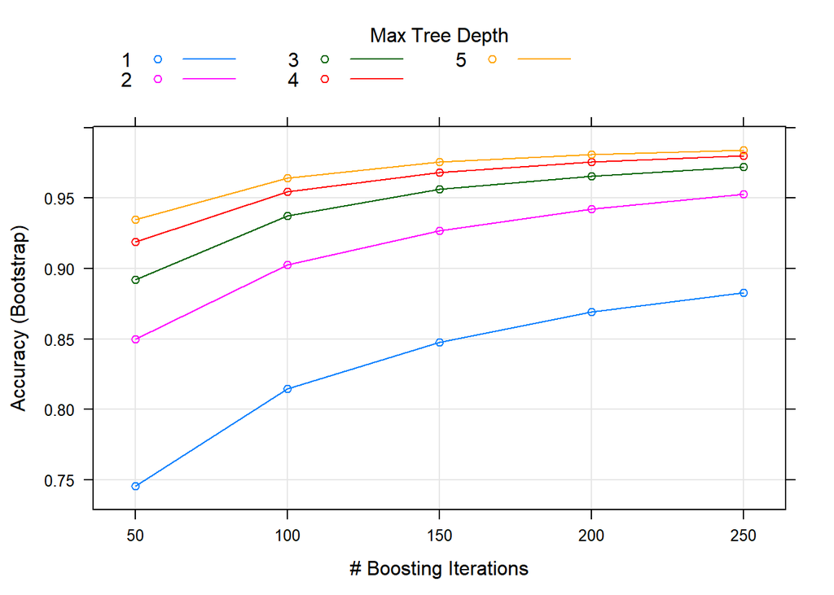

```r
mod_gbm = train(classe~.,method = 'gbm', data = train_final, verbose = F, tuneLength = 5) ## my computer cant handle the cross validation of train_control, ran without CV and default settings

# show ideal tree depth
plot(mod_gbm)
```

```r
predict_gbm = predict(mod_gbm,newdata = test_final)
gbm_cm = caret::confusionMatrix(test_final$classe,predict_gbm)

# prediction table
gbm_cm$table
```

```
##           Reference
## Prediction    A    B    C    D    E
##          A 1670    4    0    0    0
##          B    6 1128    5    0    0
##          C    0    7 1012    7    0
##          D    0    0   12  952    0
##          E    0    0    4    7 1071
```

```r
#overall accuracy
percent(gbm_cm$overall[1])
```

```
## Accuracy
##   99.12%
```

Random Forest model - Insufficient processing power to run this; including as example

```r
### Not run: don't have the computational power to run this
# control_rf <- trainControl(method="cv", number=3, verboseIter=F)
# mod_rf = train(classe~.,method = 'rf', data = train_final, tuneLength = 5) ## my computer cant handle the cross validation of train_control, ran without CV and default settings

# predict_rf = predict(mod_rf,newdata = test_final)
# rf_cm = caret::confusionMatrix(test_final$classe,predict_rf)

# prediction table
# rf_cm$table
#overall accuracy
# percent(rf_cm$overall[1])
```

The boosting model with an interaction depth of 5 gave an accuracy of 99.12%. We will therefore use this to predict the class of the samples in the validation set.

Validation results

```r
## these will be used for the final quiz
validation_results = predict(mod_gbm, val_clean)
validation_results
```

```
##  [1] B A B A A E D B A A B C B A E E A B B B
## Levels: A B C D E
```